# Denoising Diffusion Implicit Models (DDIM)

# Understanding `diff_sample`: The Generic Diffusion Sampling Function

## The Function

```
def diff_sample(model, sz, sched, **kwargs):
    x_t = torch.randn(sz).cuda()
    preds = []

    for t in progress_bar(sched.timesteps):
        with torch.no_grad():
            noise = model(x_t, t).sample
        x_t = sched.step(noise, t, x_t, **kwargs).prev_sample
        preds.append(x_t.float().cpu())

    return preds
```

This function generates images by running the **reverse diffusion process** — starting from pure random noise and iteratively denoising it into a clean image. It is designed to work with any HuggingFace `diffusers` scheduler, making it a single function that can do both DDPM (1000-step) and DDIM (any number of steps) sampling.

## Why This Function Exists

Notebook 19 (training) has separate, hardcoded sampling functions: `sample()` for full 1000-step DDPM, `sample_skip()` for skip-every-3rd, and `sample2()` for logarithmic skipping. Each one reimplements the DDPM update formula manually and has a different skipping strategy baked in. This is repetitive and inflexible.

Notebook 20 (DDIM) replaces all of them with `diff_sample`, which **delegates the math to the scheduler**. Whether you pass a `DDPMScheduler` or a `DDIMScheduler`, the function works identically — the scheduler's `.step()` method handles the algorithm-specific update rule internally. This is the key design insight: decouple the sampling loop from the denoising algorithm.

## Line-by-Line Breakdown

### Function Signature

```
def diff_sample(model, sz, sched, **kwargs):
```

| Parameter | Type | Purpose |
| --- | --- | --- |
| `model` | `UNet2DModel` | The trained noise prediction network (loaded from `fashion_ddpm3_25.pkl`, trained in notebook 19 with $\beta_{\max}=0.01$) |
| `sz` | `tuple` | Shape of the output batch, e.g. `(2048, 1, 32, 32)` — 2048 grayscale 32×32 images |
| `sched` | `DDPMScheduler` or `DDIMScheduler` | A HuggingFace scheduler that defines the noise schedule and update rule |
| `**kwargs` | `dict` | Extra arguments forwarded to `sched.step()`. The most important one is $\eta$ for DDIM, which controls stochasticity ($\eta=0$ → deterministic, $\eta=1$ → equivalent to DDPM) |

### Step 1: Initialize with Pure Noise

```
x_t = torch.randn(sz).cuda()
```

This creates a tensor of standard Gaussian noise on the GPU:

$$\mathbf{x}_T \sim \mathcal{N}(\mathbf{0}, \mathbf{I})$$

This represents the starting point of the reverse process, where $T$ is the noisiest timestep.

Conceptually, this is the right-hand end of the diffusion chain:

```
Generation goes RIGHT to LEFT:

x_T (pure noise) → x_{T-1} → ... → x_1 → x_0 (clean image)
 ↑
 We start here
```

### Step 2: The Denoising Loop

```
for t in progress_bar(sched.timesteps):
```

`sched.timesteps` is a tensor of timesteps the scheduler will visit, in **descending order** (noisiest to cleanest). Its contents depend on the scheduler and configuration:

[output not shown]

This is where DDIM's speed advantage comes from: it visits far fewer timesteps. The model was trained on all 1000 timesteps, but DDIM's non-Markovian formulation allows it to **skip between non-adjacent timesteps** without breaking the math.

`progress_bar` (from `fastprogress`) wraps the loop with a visual progress indicator, which is useful since sampling can take minutes.

### Step 3: Predict the Noise

```
with torch.no_grad():
    noise = model(x_t, t).sample
```

This is the core neural network call. Let's unpack it:

- **`torch.no_grad()`** — Disables gradient tracking. During sampling we're only doing inference (no backpropagation), so this saves GPU memory and speeds things up.
- **`model(x_t, t)`** — Feeds the current noisy image and the current timestep into the UNet. The model was trained (notebook 19, Cell 58) to predict the noise $\boldsymbol{\epsilon}$ that was added to produce $\mathbf{x}_t$. In math notation, the model computes:

$$\boldsymbol{\epsilon}_\theta(\mathbf{x}_t, t)$$

where $\theta$ denotes the learned model parameters.

- **`.sample`** — The HuggingFace `UNet2DModel` returns a `UNet2DOutput` dataclass, not a raw tensor. The actual prediction tensor lives in the `.sample` attribute. This is different from notebook 19's custom `UNet` wrapper, which overrode `forward()` to return the tensor directly.

Note that in notebook 19's `sample()` function, the model call looked like `model((x_t, t_batch))` — passing a tuple. That's because notebook 19's `UNet` wrapper unpacks the tuple in its `forward()` method. Here in notebook 20, `diff_sample` calls the model with the HuggingFace interface directly: `model(x_t, t)` as separate arguments.

Also note that `t` here is a scalar (a single timestep from `sched.timesteps`), not a batch of timesteps. The HuggingFace UNet internally broadcasts it across the batch dimension.

### Step 4: Take One Denoising Step

```
x_t = sched.step(noise, t, x_t, **kwargs).prev_sample
```

This is the most important line — and the reason this function can be scheduler-agnostic. Let's break it apart:

**`sched.step(noise, t, x_t,** kwargs)`** calls the scheduler's update rule with:

- `noise` — the model's predicted $\boldsymbol{\epsilon}_\theta(\mathbf{x}_t, t)$
- `t` — the current timestep
- `x_t` — the current noisy image $\mathbf{x}_t$
- `**kwargs` — for DDIM, this passes $\eta$

What happens inside `.step()` depends entirely on the scheduler:

#### If `sched` is a `DDPMScheduler`:

It computes the DDPM reverse step:

$$\mathbf{x}_{t-1} = \frac{1}{\sqrt{\alpha_t}} \left( \mathbf{x}_t - \frac{\beta_t}{\sqrt{1 - \bar{\alpha}_t}} \, \boldsymbol{\epsilon}_\theta(\mathbf{x}_t, t) \right) + \sigma_t \, \mathbf{z}$$

where:

- $\alpha_t = 1 - \beta_t$ is the per-step signal retention
- $\bar{\alpha}_t = \displaystyle\prod_{s=1}^{t} \alpha_s$ is the cumulative signal retention
- $\sigma_t = \sqrt{\beta_t}$ is the noise standard deviation
- $\mathbf{z} \sim \mathcal{N}(\mathbf{0}, \mathbf{I})$ is fresh random noise, mandatory at every step except $t = 0$

#### If `sched` is a `DDIMScheduler`:

It computes the DDIM reverse step in three stages.

**Stage 1 — Predict the clean image $\hat{\mathbf{x}}_0$:**

$$\hat{\mathbf{x}}_0 = \frac{\mathbf{x}_t - \sqrt{1 - \bar{\alpha}_t} \;\; \boldsymbol{\epsilon}_\theta(\mathbf{x}_t, t)}{\sqrt{\bar{\alpha}_t}}$$

**Stage 2 — Compute the noise coefficient $\sigma_t$:**

$$\sigma_t = \eta \cdot \sqrt{\frac{1 - \bar{\alpha}_{t-1}}{1 - \bar{\alpha}_t}} \cdot \sqrt{1 - \frac{\bar{\alpha}_t}{\bar{\alpha}_{t-1}}}$$

**Stage 3 — Compute $\mathbf{x}_{t-1}$:**

$$\mathbf{x}_{t-1} = \underbrace{\sqrt{\bar{\alpha}_{t-1}} \;\; \hat{\mathbf{x}}_0}_{\text{direction to } \mathbf{x}_0} \;+\; \underbrace{\sqrt{1 - \bar{\alpha}_{t-1} - \sigma_t^2} \;\; \boldsymbol{\epsilon}_\theta(\mathbf{x}_t, t)}_{\text{direction pointing to } \mathbf{x}_t} \;+\; \underbrace{\sigma_t \, \mathbf{z}}_{\text{random noise}}$$

where $\mathbf{z} \sim \mathcal{N}(\mathbf{0}, \mathbf{I})$ and is only added when $\sigma_t > 0$.

The $\eta$ parameter controls stochasticity:

| $\eta$ | $\sigma_t$ | Behavior |
| --- | --- | --- |
| $0$ | $0$ | Fully deterministic — same noise $\mathbf{x}_T$ always produces the same image |
| $1$ | Matches DDPM's $\sigma_t$ | Fully stochastic — equivalent to DDPM |
| $(0, 1)$ | Interpolated | Partial randomness |

**`.prev_sample`** extracts the $\mathbf{x}_{t-1}$ tensor from the `SchedulerOutput` dataclass that `.step()` returns. The dataclass also contains `pred_original_sample` (the predicted $\hat{\mathbf{x}}_0$), but we only need the denoised next step.

The variable `x_t` is reassigned in-place each iteration, so it continuously tracks the progressively denoised image.

### Step 5: Save Intermediate Results

```
preds.append(x_t.float().cpu())
```

Each intermediate $\mathbf{x}_{t-1}$ is saved to the `preds` list. Two conversions happen:

- **`.float()`** — Converts from FP16 (half precision) to FP32 (full precision). The model runs in mixed precision on GPU for speed, but we want full precision for evaluation and display.
- **`.cpu()`** — Moves the tensor from GPU to CPU memory. Without this, storing hundreds of intermediate images would exhaust GPU RAM.

### Step 6: Return

```
return preds
```

Returns the full list of intermediate predictions. The final generated images are always `preds[-1]` — the output of the last denoising step. The notebook then scales them for display and evaluation:

```
s = (preds[-1] * 2).clamp(-1, 1)
```

The $\times 2$ is needed because the model was trained on images in the range $[-0.5, \; 0.5]$ (notebook 19 subtracts 0.5 in the transform), but FID evaluation expects $[-1, \; 1]$.

## How the Notebook Uses It

### DDPM Sampling (1000 steps, for baseline comparison)

```
sched = DDPMScheduler(beta_end=0.01)
# sched.timesteps = [999, 998, ..., 1, 0]  — all 1000 steps
preds = diff_sample(model, sz, sched)
# Takes ~8-9 minutes for 2048 images
```

### DDIM Sampling (variable steps, the main focus)

[output not shown]

The same function, same model, same noise schedule — only the scheduler and its step count change. This demonstrates DDIM's core promise: **swap the sampling algorithm without retraining**.

## Comparison with Notebook 19's Manual Sampling

Notebook 19 implements the DDPM update formula by hand inside each sampling function:

```
# Notebook 19's sample() — hardcoded DDPM math
x_0_hat = (x_t - betabar_t.sqrt() * noise) / alphabar[t].sqrt()
x_t = (x_0_hat * alphabar_t1.sqrt() * (1-alpha[t]) / betabar_t +
       x_t * alpha[t].sqrt() * betabar_t1 / betabar_t +
       sigma[t] * z)
```

This is the alternative form of the DDPM update (the $\hat{\mathbf{x}}_0$-parameterization), which first predicts the clean image and then interpolates:

$$\hat{\mathbf{x}}_0 = \frac{\mathbf{x}_t - \sqrt{\bar{\beta}_t} \;\; \boldsymbol{\epsilon}_\theta}{\sqrt{\bar{\alpha}_t}}$$$$\mathbf{x}_{t-1} = \frac{\sqrt{\bar{\alpha}_{t-1}} \;(1 - \alpha_t)}{1 - \bar{\alpha}_t} \, \hat{\mathbf{x}}_0 \;+\; \frac{\sqrt{\alpha_t} \;(1 - \bar{\alpha}_{t-1})}{1 - \bar{\alpha}_t} \, \mathbf{x}_t \;+\; \sigma_t \, \mathbf{z}$$

where $\bar{\beta}_t = 1 - \bar{\alpha}_t$.

`diff_sample` replaces all of this with a single line:

```
x_t = sched.step(noise, t, x_t, **kwargs).prev_sample
```

The math is identical — it's just encapsulated inside the scheduler object. This makes `diff_sample` cleaner, reusable, and compatible with any scheduler the `diffusers` library offers (DDPM, DDIM, DPM-Solver, UniPC, etc.), not just the ones whose math you've manually implemented.

## Summary

| Aspect | Detail |
| --- | --- |
| **Purpose** | Generate images via reverse diffusion using any HuggingFace scheduler |
| **Input** | Trained UNet model, output shape, configured scheduler, optional kwargs (e.g. $\eta$) |
| **Output** | List of progressively denoised images; final images are `preds[-1]` |
| **Key design** | Scheduler-agnostic — the same loop works for DDPM, DDIM, and beyond |
| **Model calls** | One UNet forward pass per timestep visited |
| **Speed** | Determined entirely by `len(sched.timesteps)`, set via `sched.set_timesteps(n)` for DDIM |
| **Critical requirement** | Scheduler's $\beta_{\text{end}}$ must match the training schedule ($0.01$ in this case) |

```python
# ============================================================================
# INTERACTIVE -- run this cell. It loads ./interactive_viz/9_diff_sample_explained.html
# at full width, sized to fit the visualization (setup cell near the top required).
# diff_sample: one sampling loop, any scheduler.
# ============================================================================
show_viz("interactive_viz/9_diff_sample_explained.html", height="700px")
```

[interactive chart not shown]

**The `eta` parameter:**

DDIM has a special parameter called `eta` (η) that controls randomness:

| eta | Behavior |
| --- | --- |
| 0 | Fully deterministic (same noise → same image every time) |
| 1 | Equivalent to DDPM (fully stochastic) |
| 0-1 | Interpolation between deterministic and stochastic |

`eta` tells how much noise to add.

### 🎮 Interactive: the η (eta) dial

Three sampling runs share the **same pinned starting noise x_T** and the same model — only their per-step random z differs, and η is the volume knob on that z. **Drag η and the three paths morph live**: chip ② tweens η → 0 and the paths visibly *merge into one deterministic curve* (a "MERGED" badge appears); chip ③ tweens η → 1 and they spread apart. The right panel shows σₜ across the whole schedule for several η values, plus a stacked "noise budget" bar proving the total variance never changes — η only re-slices it.

**Things to try:** at η = 0 press 🎲 *new z draws* — nothing changes (that's determinism); at η = 1 press it again; watch the three output thumbnails go from identical to different-but-all-valid.

```python
# ============================================================================
# INTERACTIVE -- run this cell. It loads ./interactive_viz/ddim_eta_explorer.html
# at full width, sized to fit the visualization (setup cell near the top required).
# Pinned same-seed runs merge at η=0, spread at η=1; live σ curves + noise-budget bar.
# ============================================================================
show_viz("interactive_viz/ddim_eta_explorer.html", height="940px")
```

```python
import gc
del preds, s   # only delete the ones that exist; skip if not defined
gc.collect()
torch.cuda.empty_cache()   # optional, tidies GPU too
```

### DDIM with 333 Steps

```python
# Sample with DDIM using 333 steps and eta=1 (stochastic)
preds = diff_sample(model, sz, sched, eta=1.)

# Scale to [-1, 1]
s = (preds[-1] * 2).clamp(-1, 1)
```

100.00% [333/333 09:34<00:00]

```python
'model' in globals()
```

```
True
```

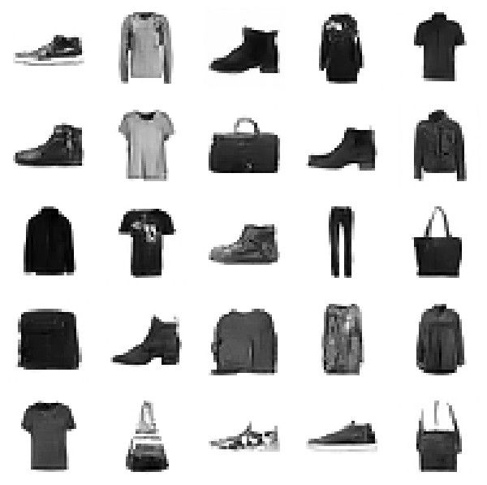

```python
# Display generated images
show_images(s[:25], imsize=1.5)
```

```python
# Evaluate quality
ie.fid(s), ie.kid(s)
```

```
(1.56927490234375, -0.0027845895383507013)
```

### DDIM with Fewer Steps

Let's see how quality changes as we reduce the number of steps.

```python
# Try 200 steps
sched.set_timesteps(200)
preds = diff_sample(model, sz, sched, eta=1.)
s = (preds[-1] * 2).clamp(-1, 1)
ie.fid(s), ie.kid(s)
```

100.00% [200/200 05:46<00:00]

```
(1.679718017578125, 0.03208513930439949)
```

# Understanding `set_timesteps(200)` - How DDIM Uses Fewer Steps

## The Code in Question

```
# Try 200 steps
sched.set_timesteps(200)
preds = diff_sample(model, sz, sched, eta=1.)
s = (preds[-1] * 2).clamp(-1, 1)
ie.fid(s), ie.kid(s)
```

## Your Question

> Does it mean that noising or forward process for adding noise works for 200 steps here?

**No!** This is a common misconception. Let me clarify:

## Important Clarification: Training vs Sampling

### The Model Was Trained with 1000 Steps

The model was **already trained** using the full 1000-step noise schedule. During training:

```
Training (Forward Process - Adding Noise):
x_0 → x_1 → x_2 → ... → x_999 → x_1000
(clean)                         (pure noise)

The model learned to predict noise at ANY of these 1000 timesteps.
```

**This training is DONE. We're not changing it.**

### `set_timesteps(200)` Only Affects Sampling (Reverse Process)

`set_timesteps(200)` tells the scheduler: "During sampling (denoising), only visit 200 timesteps instead of all 1000."

```
DDPM Sampling (1000 steps):
x_999 → x_998 → x_997 → ... → x_1 → x_0
  ↓       ↓       ↓            ↓     ↓
  All 1000 timesteps visited

DDIM Sampling with set_timesteps(200):
x_995 → x_990 → x_985 → ... → x_5 → x_0
  ↓       ↓       ↓            ↓     ↓
  Only 200 evenly-spaced timesteps visited (skipping ~5 at a time)
```

## What `set_timesteps(200)` Actually Does

### Behind the Scenes

```
sched.set_timesteps(200)

# This creates an array of 200 evenly-spaced timesteps from 999 to 0
# Something like:
sched.timesteps = [999, 994, 989, 984, ..., 9, 4, 0]
#                  ↑    ↑    ↑    ↑         ↑  ↑  ↑
#                  200 total timesteps (skipping ~5 each time)
```

### Visual Comparison

```
┌─────────────────────────────────────────────────────────────────┐
│                    TIMESTEP SELECTION                            │
├─────────────────────────────────────────────────────────────────┤
│                                                                 │
│  DDPM (1000 steps): Visit EVERY timestep                        │
│  ─────────────────────────────────────────                      │
│  999 → 998 → 997 → 996 → 995 → 994 → ... → 2 → 1 → 0           │
│   ●     ●     ●     ●     ●     ●          ●   ●   ●           │
│                                                                 │
│  DDIM with set_timesteps(200): Visit every ~5th timestep        │
│  ───────────────────────────────────────────────────            │
│  999 → 998 → 997 → 996 → 995 → 994 → ... → 2 → 1 → 0           │
│   ●                 ●                 ●              ●           │
│  (visit)         (visit)           (visit)        (visit)       │
│       ↓     ↓     ↓     ↓               ↓   ↓                   │
│      skip  skip  skip  skip           skip skip                 │
│                                                                 │
│  DDIM with set_timesteps(100): Visit every ~10th timestep       │
│  ────────────────────────────────────────────────────           │
│  999 → 998 → ... → 990 → 989 → ... → 980 → ... → 0             │
│   ●                  ●                  ●          ●            │
│                                                                 │
└─────────────────────────────────────────────────────────────────┘
```

## Why Can DDIM Skip Steps?

### DDPM Cannot Skip (Stochastic Process)

DDPM's update formula is:

```
x_{t-1} = f(x_t) + random_noise
```

Each step **depends on the random noise added**. If you skip steps, the noise accumulates incorrectly.

### DDIM Can Skip (Deterministic Option)

DDIM reformulated the math to allow **larger jumps**:

```
x_{t-Δ} = f(x_t, alphabar_t, alphabar_{t-Δ})
```

DDIM's formula uses the `alphabar` values at both the current timestep AND the target timestep. This allows it to "jump" directly from t=999 to t=994, without visiting 998, 997, 996, 995.

## The Math: How DDIM Jumps Between Non-Adjacent Timesteps

### The DDIM Update Formula

```
x_{t-1} = √(ᾱ_{t-1}) * x̂_0 + √(1 - ᾱ_{t-1} - σ²) * ε_θ(x_t, t) + σ * z
```

Where:

- `x̂_0` = predicted clean image: `(x_t - √(1-ᾱ_t) * ε_θ) / √(ᾱ_t)`
- `ᾱ_t` = alphabar at current timestep
- `ᾱ_{t-1}` = alphabar at target timestep (can be many steps away!)
- `ε_θ` = model's noise prediction
- `σ` = noise level (controlled by eta)
- `z` = random noise

### Key Insight

The formula only needs `ᾱ_t` and `ᾱ_{t-1}` - it doesn't care if they are adjacent (t and t-1) or far apart (t=999 and t-1=994).

```
┌─────────────────────────────────────────────────────────────────┐
│                    DDIM JUMP MECHANISM                           │
├─────────────────────────────────────────────────────────────────┤
│                                                                 │
│  At timestep t=999:                                             │
│    - We have x_999 (very noisy image)                          │
│    - Model predicts noise ε_θ(x_999, 999)                      │
│    - We compute predicted clean image x̂_0                      │
│                                                                 │
│  To go to t=994 (skipping 5 steps):                            │
│    - Look up ᾱ_999 and ᾱ_994 from the noise schedule           │
│    - Apply DDIM formula using both values                       │
│    - Result: x_994 directly (no need for x_998, x_997, etc.)   │
│                                                                 │
│  x_999 ─────────────────────────────────► x_994                │
│         One model call, one update step                         │
│         (equivalent to 5 DDPM steps!)                           │
│                                                                 │
└─────────────────────────────────────────────────────────────────┘
```

## Code Flow: What Happens When You Call `set_timesteps(200)`

### Step 1: Create Scheduler

```
sched = DDIMScheduler(beta_end=0.01)
```

The scheduler knows the full 1000-step noise schedule (all the `beta`, `alpha`, `alphabar` values).

### Step 2: Set Number of Sampling Steps

```
sched.set_timesteps(200)
```

This does NOT change the noise schedule. It only selects WHICH timesteps to visit:

```
# Internally, something like:
sched.timesteps = torch.linspace(999, 0, 200).long()
# Result: [999, 994, 989, 984, 979, ..., 9, 4, 0]
```

### Step 3: Sampling Loop

```
for t in progress_bar(sched.timesteps):  # Only 200 iterations!
    noise = model(x_t, t).sample
    x_t = sched.step(noise, t, x_t, eta=1.).prev_sample
```

Each iteration:

1. Model predicts noise at current timestep `t`
2. Scheduler computes `x_{t-skip}` using DDIM formula with appropriate `alphabar` values
3. We jump to the next timestep in our list (not t-1, but t-5 or whatever the spacing is)

## Summary Table

[output not shown]

## Common Misconceptions

### ❌ Misconception 1: "The model is retrained with 200 steps"

**Reality:** The model is NOT retrained. It was trained once with 1000 steps and remains unchanged. DDIM just uses the same model differently during sampling.

### ❌ Misconception 2: "The noise schedule changes to 200 steps"

**Reality:** The noise schedule stays at 1000 steps. DDIM just looks up the `alphabar` values for the specific timesteps it visits (e.g., `alphabar[999]`, `alphabar[994]`, etc.).

### ❌ Misconception 3: "set_timesteps affects the forward (noising) process"

**Reality:** The forward process (training) is already done. `set_timesteps` only affects the reverse process (sampling/denoising).

## Visual Summary

```
┌─────────────────────────────────────────────────────────────────┐
│                    TRAINING vs SAMPLING                          │
├─────────────────────────────────────────────────────────────────┤
│                                                                 │
│  TRAINING (Done once, uses all 1000 timesteps):                 │
│  ─────────────────────────────────────────────                  │
│                                                                 │
│    Clean Image → Add noise at random t ∈ [0, 999] → Model      │
│                                                    learns to    │
│                                                    predict noise│
│                                                                 │
│    This created the model weights. FINISHED. UNCHANGEABLE.      │
│                                                                 │
│  ═══════════════════════════════════════════════════════════   │
│                                                                 │
│  SAMPLING with set_timesteps(200):                              │
│  ─────────────────────────────────                              │
│                                                                 │
│    Pure Noise (x_999)                                          │
│         │                                                       │
│         ▼ (model predicts noise, DDIM jumps to t=994)          │
│    x_994                                                        │
│         │                                                       │
│         ▼ (model predicts noise, DDIM jumps to t=989)          │
│    x_989                                                        │
│         │                                                       │
│        ...  (repeat 200 times total)                           │
│         │                                                       │
│         ▼                                                       │
│    Clean Image (x_0)                                           │
│                                                                 │
└─────────────────────────────────────────────────────────────────┘
```

## Final Answer

**`set_timesteps(200)` does NOT mean the forward/noising process uses 200 steps.**

It means:

1. The model was trained with the full 1000-step schedule (this is fixed)
2. During sampling, we only visit 200 evenly-spaced timesteps
3. DDIM's math allows us to "jump" between non-adjacent timesteps
4. This makes generation 5x faster (200 vs 1000 model calls) with minimal quality loss

```python
# ============================================================================
# INTERACTIVE -- run this cell. It loads ./interactive_viz/10_set_timesteps_explained.html
# at full width, sized to fit the visualization (setup cell near the top required).
# set_timesteps(200): the sampling dial that never touches training.
# ============================================================================
show_viz("interactive_viz/10_set_timesteps_explained.html", height="700px")
```

[interactive chart not shown]

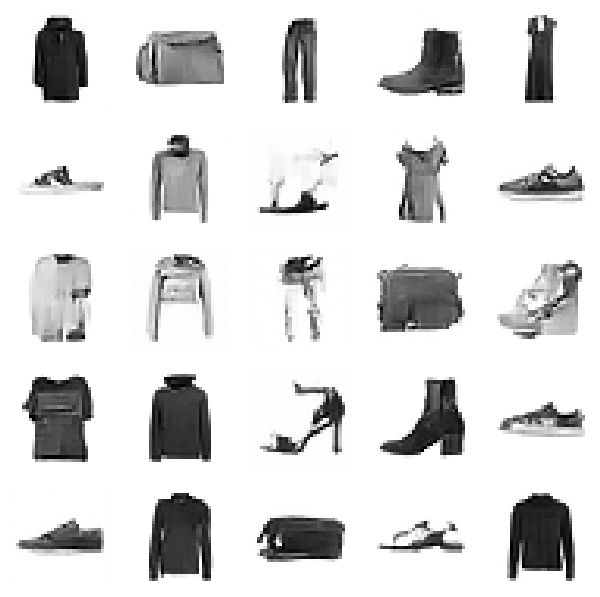

```python
# Display 200-step samples
show_images(s[:25], imsize=1.5)
```

```python
# Try 100 steps
sched.set_timesteps(100)
preds = diff_sample(model, sz, sched, eta=1.)
```

100.00% [100/100 02:52<00:00]

```python
s = (preds[-1] * 2).clamp(-1, 1)
```

```python
ie.fid(s), ie.kid(s)
```

```
(3.224853515625, 0.024972474202513695)
```

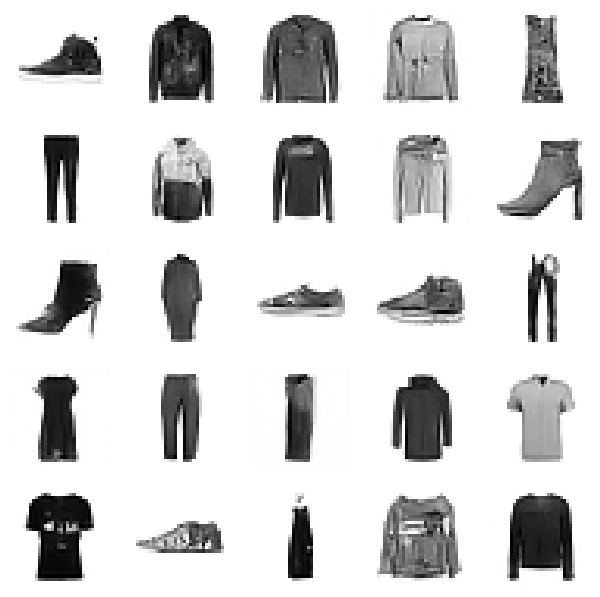

```python
# Display 100-step samples
show_images(s[:25], imsize=1.5)
```

```python
# Try 50 steps
sched.set_timesteps(50)
preds = diff_sample(model, sz, sched, eta=1.)
s = (preds[-1] * 2).clamp(-1, 1)
ie.fid(s), ie.kid(s)
```

100.00% [50/50 01:26<00:00]

```
(4.75787353515625, 0.04975477233529091)
```

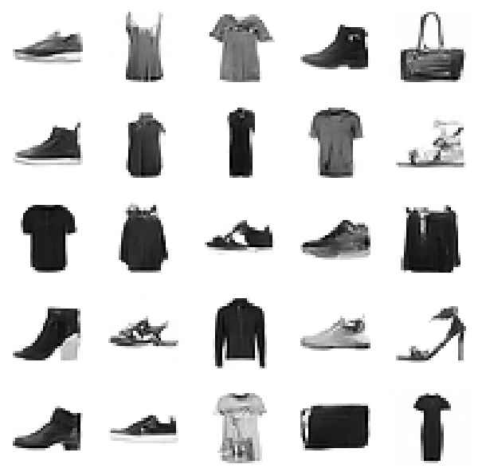

```python
# Display 50-step samples
show_images(s[:25], imsize=1.5)
```

```python
# Try 25 steps (pushing the limit)
sched.set_timesteps(25)
preds = diff_sample(model, sz, sched, eta=1.)
s = (preds[-1] * 2).clamp(-1, 1)
ie.fid(s), ie.kid(s)
```

100.00% [25/25 00:43<00:00]

```
(9.655059814453125, 0.1369989961385727)
```

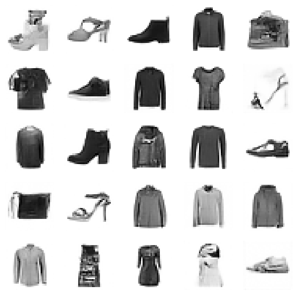

```python
# Display 25-step samples
show_images(s[:25], imsize=1.5)
```

### Summary: Steps vs Quality

[output not shown]

**Takeaway**: DDIM with 100-200 steps gives a good balance between speed and quality.

## Implementing DDIM from Scratch

Now let's understand how DDIM actually works by implementing it ourselves.

```python
# SimpleNamespace for bundling schedule values
from types import SimpleNamespace
```

```python
# Total diffusion steps (what the model was trained with)
n_steps = 1000
```

```python
def linear_sched(betamin=0.0001, betamax=0.02, n_steps=1000):
    """
    Create a linear noise schedule.

    Args:
        betamin: Starting variance
        betamax: Ending variance
        n_steps: Total timesteps

    Returns:
        SimpleNamespace with alpha, alphabar, and sigma values
    """
    # Linear spacing of beta from betamin to betamax
    beta = torch.linspace(betamin, betamax, n_steps)

    return SimpleNamespace(
        a=1.-beta,                    # alpha = 1 - beta
        abar=(1.-beta).cumprod(dim=0), # alphabar = cumulative product of alphas
        sig=beta.sqrt()               # sigma = sqrt(beta)
    )
```

```python
# Create schedule matching what model was trained with
sc = linear_sched(betamax=0.01, n_steps=n_steps)
abar = sc.abar  # We mainly need alphabar for DDIM
```

[figure not shown]

### The DDIM Update Formula

The DDIM paper introduces a generalized update rule:

```
x_{t-1} = √(ᾱ_{t-1}) * x̂_0 + √(1 - ᾱ_{t-1} - σ²) * ε_θ(x_t, t) + σ * z
```

Where:

- `x̂_0` = predicted clean image from current noisy image
- `ε_θ(x_t, t)` = model's noise prediction
- `σ` = noise level (controlled by eta)
- `z` = random noise (only if σ > 0)

The predicted clean image is:

```
x̂_0 = (x_t - √(1-ᾱ_t) * ε_θ) / √(ᾱ_t)
```

```python
def ddim_step(x_t, t, noise, abar_t, abar_t1, bbar_t, bbar_t1, eta):
    """
    Perform one DDIM update step.

    This implements the DDIM formula to go from x_t to x_{t-1}.

    Args:
        x_t: Current noisy image
        t: Current timestep
        noise: Model's predicted noise (epsilon)
        abar_t: alphabar at timestep t
        abar_t1: alphabar at timestep t-1
        bbar_t: 1 - alphabar_t (betabar at t)
        bbar_t1: 1 - alphabar_{t-1} (betabar at t-1)
        eta: Noise coefficient (0=deterministic, 1=DDPM)

    Returns:
        x_{t-1}: The denoised image at the next timestep
    """
    # Calculate variance for this step
    # This formula ensures the variance is consistent with the noise schedule
    vari = (bbar_t1 / bbar_t) * (1 - abar_t / abar_t1)

    # Scale variance by eta (eta=0 → no variance, eta=1 → full variance)
    sig = vari.sqrt() * eta

    # Predict x_0 from x_t and noise prediction
    # Formula: x_0 = (x_t - sqrt(1-alphabar_t) * noise) / sqrt(alphabar_t)
    x_0_hat = (x_t - bbar_t.sqrt() * noise) / abar_t.sqrt()

    # Compute x_{t-1} using DDIM formula
    # x_{t-1} = sqrt(alphabar_{t-1}) * x_0_hat + sqrt(1-alphabar_{t-1}-sig^2) * noise
    x_t = abar_t1.sqrt() * x_0_hat + (bbar_t1 - sig**2).sqrt() * noise

    # Add noise (only if not at final step and eta > 0)
    if t > 0:
        x_t += sig * torch.randn(x_t.shape).to(x_t)

    return x_t
```

**Understanding the DDIM step:**

```
Step 1: Predict x_0
   x̂_0 = (x_t - √β̄_t * ε) / √ᾱ_t
         ↑                    ↑
    Remove noise        Scale back up

Step 2: Move toward x_{t-1}
   x_{t-1} = √ᾱ_{t-1} * x̂_0 + √(β̄_{t-1} - σ²) * ε
             ↑                 ↑
        Scale x_0          Add back some noise

Step 3: Add random noise (if eta > 0)
   x_{t-1} += σ * z
              ↑   ↑
           sigma  random noise

When eta=0: σ=0, no random noise added → deterministic
When eta=1: Full σ, same as DDPM → stochastic
```

### 🎮 Interactive: `ddim_step`, line by line — with live numbers

The exact function defined above, walkable. **Click any code line** to jump to its explanation, and the live panel plugs *real schedule values* into every symbol at your chosen `t`, `skips`, and `η`. New in this version: the **variance-budget square** — three rectangles (signal ᾱₜ′, recycled direction β̄ₜ′−σ², fresh σ²) that always tile the unit square exactly, with an arrow diagram whose lengths are the three coefficients.

```python
# ============================================================================
# INTERACTIVE -- run this cell. It loads ./interactive_viz/ddim_step_walkthrough.html
# at full width, sized to fit the visualization (setup cell near the top required).
# Clickable code ↔ stages, live schedule numbers, variance-budget square + arrow diagram.
# ============================================================================
show_viz("interactive_viz/ddim_step_walkthrough.html", height="960px")
```

[interactive chart not shown]

# Understanding the Variance Calculation in DDIM

## The Code in Question

```
# Calculate variance for this step
# This formula ensures the variance is consistent with the noise schedule
vari = (bbar_t1 / bbar_t) * (1 - abar_t / abar_t1)

# Scale variance by eta (eta=0 → no variance, eta=1 → full variance)
sig = vari.sqrt() * eta
```

$$x_{t-1} = \sqrt{\bar{\alpha}_{t-1}} \underbrace{\left(\frac{x_t - \sqrt{1-\bar{\alpha}_t} \epsilon_\theta^{(t)}(x_t)}{\sqrt{\bar{\alpha}_t}}\right)}_{\text{"predicted } x_0\text{"}} + \underbrace{\sqrt{1-\bar{\alpha}_{t-1} - \sigma_t^2} \cdot \epsilon_\theta^{(t)}(x_t)}_{\text{"direction pointing to } x_t\text{"}} + \underbrace{\sigma_t \epsilon_t}_{\text{random noise}}$$

Where:

- **Term 1**: $\sqrt{\bar{\alpha}_{t-1}} \cdot \hat{x}_0$ — Scaled predicted clean image
- **Term 2**: $\sqrt{1-\bar{\alpha}_{t-1} - \sigma_t^2} \cdot \epsilon_\theta^{(t)}(x_t)$ — Direction pointing back toward the noisy image
- **Term 3**: $\sigma_t \epsilon_t$ — Random noise (controlled by σ)

## What Are These Lines Calculating?

```
vari = (bbar_t1 / bbar_t) * (1 - abar_t / abar_t1)
sig = vari.sqrt() * eta
```

These lines calculate **$\sigma_t$** (sigma) - the coefficient for the **random noise term** (Term 3) in the DDIM formula.

```
┌─────────────────────────────────────────────────────────────────┐
│                                                                 │
│  vari = (bbar_t1/bbar_t) * (1 - abar_t/abar_t1)   ← This is σ² │
│  sig = vari.sqrt() * eta                           ← This is σ  │
│                                                                 │
└─────────────────────────────────────────────────────────────────┘
```

## Step-by-Step Breakdown

### Line 1: Calculate the Variance ($\sigma^2$)

```
vari = (bbar_t1 / bbar_t) * (1 - abar_t / abar_t1)
```

**What this computes:**

$$\sigma_t^2 = \frac{\bar{\beta}_{t-1}}{\bar{\beta}_t} \cdot \left(1 - \frac{\bar{\alpha}_t}{\bar{\alpha}_{t-1}}\right)$$

Where:

- `bbar_t` = $\bar{\beta}_t = 1 - \bar{\alpha}_t$
- `bbar_t1` = $\bar{\beta}_{t-1} = 1 - \bar{\alpha}_{t-1}$
- `abar_t` = $\bar{\alpha}_t$ (alphabar at timestep t)
- `abar_t1` = $\bar{\alpha}_{t-1}$ (alphabar at timestep t-1)

**This is the DDPM posterior variance formula** - it ensures the noise added is consistent with the original noise schedule.

### Line 2: Scale by Eta and Take Square Root

```
sig = vari.sqrt() * eta
```

**What this computes:**

$$\sigma_t = \eta \cdot \sqrt{\text{vari}}$$

Where:

- `eta` ($\eta$) controls how much randomness to add
- $\eta = 0 \rightarrow \sigma = 0 \rightarrow$ **deterministic** (no random noise)
- $\eta = 1 \rightarrow \sigma = $ full DDPM variance $\rightarrow$ **stochastic** (same as DDPM)

## Visual: Where $\sigma_t$ Appears in the Formula

```
┌─────────────────────────────────────────────────────────────────┐
│                    DDIM FORMULA BREAKDOWN                        │
├─────────────────────────────────────────────────────────────────┤
│                                                                 │
│  x_{t-1} = √ᾱ_{t-1} * x̂_0 + √(1-ᾱ_{t-1}-σ²) * ε + σ * z       │
│            ─────────────   ─────────────────────   ─────        │
│                 │                    │                │         │
│                 │                    │                │         │
│                 ▼                    ▼                ▼         │
│           Term 1:              Term 2:           Term 3:        │
│         Predicted x_0      Direction to x_t    Random noise     │
│                                                                 │
│                                    │                │           │
│                                    │                │           │
│                              ┌─────┴─────┐    ┌────┴────┐      │
│                              │           │    │         │      │
│                              │  Uses σ²  │    │ Uses σ  │      │
│                              │           │    │         │      │
│                              └───────────┘    └─────────┘      │
│                                                                 │
│  The lines you asked about calculate σ (sig):                  │
│                                                                 │
│    vari = (bbar_t1/bbar_t) * (1 - abar_t/abar_t1)  ← σ²       │
│    sig = vari.sqrt() * eta                          ← σ        │
│                                                                 │
└─────────────────────────────────────────────────────────────────┘
```

## How $\sigma$ Affects the Three Terms

```
┌─────────────────────────────────────────────────────────────────┐
│                    EFFECT OF η (eta) ON σ                        │
├─────────────────────────────────────────────────────────────────┤
│                                                                 │
│  η = 0 (Deterministic DDIM):                                   │
│  ──────────────────────────                                     │
│    σ = 0                                                        │
│    x_{t-1} = √ᾱ_{t-1} * x̂_0 + √(1-ᾱ_{t-1}) * ε + 0           │
│                                                    ↑            │
│                                              No random noise    │
│    Same starting noise → Same final image (reproducible!)       │
│                                                                 │
│  ─────────────────────────────────────────────────────────────  │
│                                                                 │
│  η = 1 (Stochastic, same as DDPM):                             │
│  ─────────────────────────────────                              │
│    σ = √vari (full variance)                                   │
│    x_{t-1} = √ᾱ_{t-1} * x̂_0 + √(1-ᾱ_{t-1}-σ²) * ε + σ * z    │
│                                                        ↑        │
│                                              Random noise added │
│    Same starting noise → Different final images (stochastic)    │
│                                                                 │
│  ─────────────────────────────────────────────────────────────  │
│                                                                 │
│  0 < η < 1 (Interpolation):                                    │
│  ──────────────────────────                                     │
│    σ = η * √vari (partial variance)                            │
│    Somewhere between deterministic and stochastic               │
│                                                                 │
└─────────────────────────────────────────────────────────────────┘
```

## Mathematical Derivation of vari

The variance formula comes from ensuring the marginal distribution remains correct:

$$\sigma_t^2 = \frac{1 - \bar{\alpha}_{t-1}}{1 - \bar{\alpha}_t} \cdot \left(1 - \frac{\bar{\alpha}_t}{\bar{\alpha}_{t-1}}\right)$$

In code notation:

```
vari = (bbar_t1 / bbar_t) * (1 - abar_t / abar_t1)
#       ↑                   ↑
#       (1-ᾱ_{t-1})/(1-ᾱ_t)   (1 - ᾱ_t/ᾱ_{t-1})
```

This can also be written as:

$$\sigma_t^2 = \frac{\beta_t (1 - \bar{\alpha}_{t-1})}{1 - \bar{\alpha}_t}$$

This is the **posterior variance** from DDPM - the variance you'd need to add to maintain the correct noise level at each step.

## How These Values Are Used Later in the Code

```
# The sig value is used in TWO places:

# 1. In the "direction pointing to x_t" term (Term 2)
x_t = abar_t1.sqrt() * x_0_hat + (bbar_t1 - sig**2).sqrt() * noise
#                                 ↑
#                           Uses sig² here
#                           √(1 - ᾱ_{t-1} - σ²)

# 2. In the random noise term (Term 3)
if t > 0:
    x_t += sig * torch.randn(x_t.shape).to(x_t)
    #      ↑
    #    Uses sig here
    #    σ * z (random noise)
```

## Mapping Code to Formula

```
┌─────────────────────────────────────────────────────────────────┐
│                    CODE TO FORMULA MAPPING                       │
├─────────────────────────────────────────────────────────────────┤
│                                                                 │
│  FORMULA:                                                       │
│  x_{t-1} = √ᾱ_{t-1} * x̂_0 + √(1-ᾱ_{t-1}-σ²) * ε + σ * z       │
│                                                                 │
│  CODE:                                                          │
│  ─────                                                          │
│                                                                 │
│  # Variance calculation (your question)                         │
│  vari = (bbar_t1 / bbar_t) * (1 - abar_t / abar_t1)  → σ²      │
│  sig = vari.sqrt() * eta                              → σ       │
│                                                                 │
│  # Predicted x_0                                                │
│  x_0_hat = (x_t - bbar_t.sqrt() * noise) / abar_t.sqrt()       │
│            ↑                                                    │
│            (x_t - √(1-ᾱ_t) * ε) / √ᾱ_t                        │
│                                                                 │
│  # Main update (Terms 1 + 2)                                    │
│  x_t = abar_t1.sqrt() * x_0_hat + (bbar_t1 - sig**2).sqrt() * noise
│        ↑                          ↑                              │
│        √ᾱ_{t-1} * x̂_0             √(1-ᾱ_{t-1}-σ²) * ε          │
│                                                                 │
│  # Random noise (Term 3)                                        │
│  x_t += sig * torch.randn(...)                                 │
│         ↑                                                       │
│         σ * z                                                   │
│                                                                 │
└─────────────────────────────────────────────────────────────────┘
```

### Detailed Code-to-Math Mapping

| Code | Mathematical Expression | Description |
| --- | --- | --- |
| `vari` | $\sigma_t^2 = \frac{\bar{\beta}_{t-1}}{\bar{\beta}_t} \cdot \left(1 - \frac{\bar{\alpha}_t}{\bar{\alpha}_{t-1}}\right)$ | Variance |
| `sig` | $\sigma_t = \eta \cdot \sqrt{\sigma_t^2}$ | Standard deviation scaled by η |
| `x_0_hat` | $\hat{x}_0 = \frac{x_t - \sqrt{1-\bar{\alpha}_t} \cdot \epsilon_\theta}{\sqrt{\bar{\alpha}_t}}$ | Predicted clean image |
| `abar_t1.sqrt() * x_0_hat` | $\sqrt{\bar{\alpha}_{t-1}} \cdot \hat{x}_0$ | Term 1 |
| `(bbar_t1 - sig**2).sqrt() * noise` | $\sqrt{1-\bar{\alpha}_{t-1}-\sigma_t^2} \cdot \epsilon_\theta$ | Term 2 |
| `sig * torch.randn(...)` | $\sigma_t \cdot \epsilon_t$ | Term 3 |

## Why This Formula for Variance?

The variance formula ensures that **the noise schedule remains consistent** when we skip timesteps.

```
┌─────────────────────────────────────────────────────────────────┐
│                    WHY THIS SPECIFIC FORMULA?                    │
├─────────────────────────────────────────────────────────────────┤
│                                                                 │
│  In DDPM, when going from x_t to x_{t-1}:                      │
│                                                                 │
│    - We remove some noise (predicted by model)                  │
│    - We add back some noise (to maintain stochasticity)         │
│                                                                 │
│  The amount of noise to add back is NOT arbitrary!              │
│  It must match the noise schedule so that:                      │
│                                                                 │
│    q(x_{t-1} | x_t, x_0) has the correct variance               │
│                                                                 │
│  This posterior variance is:                                    │
│                                                                 │
│    σ² = β_t * (1-ᾱ_{t-1}) / (1-ᾱ_t)                           │
│                                                                 │
│  Which is equivalent to:                                        │
│                                                                 │
│    σ² = (bbar_t1/bbar_t) * (1 - abar_t/abar_t1)                │
│                                                                 │
│  DDIM's insight: Multiply by η to control the randomness!       │
│                                                                 │
│    σ_final = η * √(σ²)                                         │
│                                                                 │
└─────────────────────────────────────────────────────────────────┘
```

## Summary Tables

### What Each Line Calculates

| Line | What It Calculates | Mathematical Expression |
| --- | --- | --- |
| `vari = ...` | $\sigma^2$ (variance) | $\sigma_t^2 = \frac{\bar{\beta}_{t-1}}{\bar{\beta}_t} \cdot \left(1 - \frac{\bar{\alpha}_t}{\bar{\alpha}_{t-1}}\right)$ |
| `sig = vari.sqrt() * eta` | $\sigma$ (standard deviation) | $\sigma_t = \eta \cdot \sqrt{\sigma_t^2}$ |

### Effect of $\eta$ (eta) on Behavior

| $\eta$ Value | $\sigma$ Value | Behavior | Result |
| --- | --- | --- | --- |
| 0 | 0 | Fully deterministic | Same noise → Same image |
| 0.5 | Half of DDPM | Partially stochastic | Some variation |
| 1 | Full DDPM variance | Fully stochastic | Same noise → Different images |

### Where $\sigma$ is Used in the DDIM Formula

| Location in Code | Mathematical Expression | Term in Formula |
| --- | --- | --- |
| `(bbar_t1 - sig**2).sqrt()` | $\sqrt{1-\bar{\alpha}_{t-1}-\sigma_t^2}$ | "Direction pointing to $x_t$" |
| `sig * torch.randn(...)` | $\sigma_t \cdot \epsilon_t$ | "Random noise" |

## Key Insight

**The variance calculation ensures the noise schedule remains mathematically consistent**, while **$\eta$ gives you control over how much randomness to add**:

- $\eta = 0$: Skip the random noise entirely → deterministic, reproducible results
- $\eta = 1$: Use the full DDPM variance → stochastic, equivalent to original DDPM
- $0 < \eta < 1$: Interpolate between the two extremes

```python
# ============================================================================
# INTERACTIVE -- run this cell. It loads ./interactive_viz/11_ddim_variance_explained.html
# at full width, sized to fit the visualization (setup cell near the top required).
# vari & sig: the DDIM variance lines, decoded.
# ============================================================================
show_viz("interactive_viz/11_ddim_variance_explained.html", height="700px")
```

[interactive chart not shown]

# Understanding the $\epsilon_\theta^{(t)}(x_t)$ Notation in DDIM

## The Confusion

Looking at the DDIM formula:

$$x_{t-1} = \sqrt{\alpha_{t-1}} \left(\frac{x_t - \sqrt{1-\alpha_t} \epsilon_\theta^{(t)}(x_t)}{\sqrt{\alpha_t}}\right) + \ldots$$

You asked: Should the code be this?

```
# WRONG interpretation
x_0_hat = (x_t - bbar_t.sqrt() * noise * x_t) / abar_t.sqrt()
```

**No!** The original code is correct:

```
# CORRECT
x_0_hat = (x_t - bbar_t.sqrt() * noise) / abar_t.sqrt()
```

## Understanding the Notation

In the equation:

$$\epsilon_\theta^{(t)}(x_t)$$

This is **NOT** multiplication! Let me break it down:

```
┌─────────────────────────────────────────────────────────────────┐
│                    NOTATION BREAKDOWN                            │
├─────────────────────────────────────────────────────────────────┤
│                                                                 │
│   ε_θ^(t)(x_t)                                                  │
│   ↑ ↑  ↑   ↑                                                    │
│   │ │  │   │                                                    │
│   │ │  │   └── (x_t) = INPUT to the function (the noisy image) │
│   │ │  │                                                        │
│   │ │  └────── (t) = superscript indicating timestep            │
│   │ │                                                           │
│   │ └────────── θ = subscript indicating model parameters       │
│   │                                                             │
│   └──────────── ε = epsilon (the function that predicts noise)  │
│                                                                 │
│   In plain English: "The noise predicted by model θ at time t,  │
│                      given input x_t"                           │
│                                                                 │
│   In code: model(x_t, t).sample  OR  noise                     │
│                                                                 │
└─────────────────────────────────────────────────────────────────┘
```

## It's Function Notation, Not Multiplication!

$$\epsilon_\theta^{(t)}(x_t) = \text{model}(x_t, t)$$

The parentheses around $x_t$ indicate that $x_t$ is the **input argument** to the function $\epsilon_\theta$, just like in:

| Math Notation | Meaning |
| --- | --- |
| $f(x)$ | "f of x" — function f applied to x |
| $\sin(x)$ | "sine of x" — sine function applied to x |
| $\epsilon_\theta^{(t)}(x_t)$ | "noise predictor applied to $x_t$ at timestep t" |

## Visual Comparison

```
┌─────────────────────────────────────────────────────────────────┐
│                                                                 │
│  ❌ WRONG interpretation (multiplication):                      │
│  ──────────────────────────────────────────                     │
│                                                                 │
│    √(1-ᾱ_t) * ε_θ * x_t                                        │
│                    ↑                                            │
│              Multiplying by x_t? NO!                           │
│                                                                 │
│  ───────────────────────────────────────────────────────────── │
│                                                                 │
│  ✓ CORRECT interpretation (function application):              │
│  ─────────────────────────────────────────────────             │
│                                                                 │
│    √(1-ᾱ_t) * ε_θ(x_t)                                         │
│                  ↑                                              │
│           Function taking x_t as input                         │
│           This whole thing = "noise" in code                   │
│                                                                 │
└─────────────────────────────────────────────────────────────────┘
```

## Code Mapping

```
# In the sampling loop, we FIRST get the noise prediction:
noise = model(x_t, t).sample
#       ↑
#       This IS ε_θ^(t)(x_t) - the model predicting noise given x_t

# THEN we use it in the formula:
x_0_hat = (x_t - bbar_t.sqrt() * noise) / abar_t.sqrt()
#                                ↑
#                         Already contains the model's
#                         prediction for the given x_t
```

## The Full Picture

```
for i, t in enumerate(progress_bar(tsteps)):
    # Step 1: Model predicts noise (this is ε_θ^(t)(x_t))
    noise = model(x_t, t).sample
    #            ↑    ↑
    #           x_t   t
    #       ε_θ^(t)(x_t) in math notation

    # Step 2: Use the noise prediction in the DDIM formula
    x_0_hat = (x_t - bbar_t.sqrt() * noise) / abar_t.sqrt()
    #                                ↑
    #                    noise = ε_θ^(t)(x_t)
    #                    (already computed above)
```

## Math-to-Code Translation

### The "Predicted $x_0$" Term

**Math:** $$\hat{x}_0 = \frac{x_t - \sqrt{1-\bar{\alpha}_t} \cdot \epsilon_\theta^{(t)}(x_t)}{\sqrt{\bar{\alpha}_t}}$$

**Code:**

```
# First, get the noise prediction (this is ε_θ^(t)(x_t))
noise = model(x_t, t).sample

# Then compute x_0_hat
x_0_hat = (x_t - bbar_t.sqrt() * noise) / abar_t.sqrt()
#          ↑     ↑                ↑       ↑
#          x_t   √(1-ᾱ_t)        ε_θ(x_t)  √ᾱ_t
```

### Mapping Table

| Math Symbol | Code Variable | Description |
| --- | --- | --- |
| $x_t$ | `x_t` | Current noisy image |
| $\sqrt{1-\bar{\alpha}_t}$ | `bbar_t.sqrt()` | Square root of betabar |
| $\epsilon_\theta^{(t)}(x_t)$ | `noise` or `model(x_t, t).sample` | Model's noise prediction |
| $\sqrt{\bar{\alpha}_t}$ | `abar_t.sqrt()` | Square root of alphabar |
| $\hat{x}_0$ | `x_0_hat` | Predicted clean image |

## Common Notation Patterns in ML Papers

| Notation | Meaning | NOT |
| --- | --- | --- |
| $f(x)$ | Function f applied to x | f times x |
| $f_\theta(x)$ | Neural network with parameters θ applied to x | f times θ times x |
| $\epsilon_\theta(x_t)$ | Noise predictor applied to $x_t$ | ε times θ times $x_t$ |
| $\epsilon_\theta^{(t)}(x_t)$ | Noise predictor at timestep t applied to $x_t$ | ε times θ times t times $x_t$ |

## Summary

| Question | Answer |
| --- | --- |
| What does $\epsilon_\theta^{(t)}(x_t)$ mean? | A function (the model) that takes $x_t$ as input |
| Is $(x_t)$ multiplication? | **NO!** It's the function's input argument |
| What is `noise` in code? | The result of $\epsilon_\theta^{(t)}(x_t)$ — already computed |
| Is the original code correct? | **YES!** `x_0_hat = (x_t - bbar_t.sqrt() * noise) / abar_t.sqrt()` |

## Key Takeaway

The parentheses in $\epsilon_\theta^{(t)}(x_t)$ denote **function application**, not multiplication.

In code, we first compute this function:

```
noise = model(x_t, t).sample  # This IS ε_θ^(t)(x_t)
```

Then we use the result:

```
x_0_hat = (x_t - bbar_t.sqrt() * noise) / abar_t.sqrt()
```

The `noise` variable already contains the model's prediction for the given $x_t$ — no need to multiply by $x_t$ again!

```python
# ============================================================================
# INTERACTIVE -- run this cell. It loads ./interactive_viz/12_eps_theta_notation.html
# at full width, sized to fit the visualization (setup cell near the top required).
# eps_theta^(t)(x_t): function application, not multiplication.
# ============================================================================
show_viz("interactive_viz/12_eps_theta_notation.html", height="700px")
```

[interactive chart not shown]

```python
@torch.no_grad()
def sample(f, model, sz, n_steps, skips=1, eta=1.):
    """
    Sample images using a custom step function.

    This is a flexible sampling function that can work with different
    step functions (DDPM, DDIM, etc.).

    Args:
        f: Step function (e.g., ddim_step)
        model: Trained noise prediction model
        sz: Shape of images to generate
        n_steps: Total number of diffusion steps
        skips: Skip every N steps (skips=10 means use only 1/10 of steps)
        eta: Noise coefficient for DDIM

    Returns:
        List of intermediate predictions
    """
    # Create list of timesteps to use (reversed, with skipping)
    # e.g., skips=10, n_steps=1000 → [990, 980, 970, ..., 10, 0]
    tsteps = list(reversed(range(0, n_steps, skips)))

    # Start from random noise
    x_t = torch.randn(sz).to(model.device)
    preds = []

    for i, t in enumerate(progress_bar(tsteps)):
        # Get alphabar for next timestep (or 1 if at final step)
        abar_t1 = abar[tsteps[i+1]] if t > 0 else torch.tensor(1)

        # Model predicts noise
        noise = model(x_t, t).sample

        # Take one step using the provided function
        x_t = f(
            x_t, t, noise,
            abar[t],      # alphabar at t
            abar_t1,      # alphabar at t-1 (or next used timestep)
            1-abar[t],    # betabar at t
            1-abar_t1,    # betabar at t-1
            eta
        )

        preds.append(x_t.float().cpu())

    return preds
```

**How skipping works:**

```
Original timesteps (n_steps=1000):
[999, 998, 997, ..., 2, 1, 0]  → 1000 steps

With skips=10:
[990, 980, 970, ..., 20, 10, 0]  → 100 steps

With skips=100:
[900, 800, 700, ..., 200, 100, 0]  → 10 steps
```

The key insight: When we skip timesteps, we use the alphabar values for the timesteps we actually visit. This is why DDIM works - it's designed to handle non-adjacent timesteps.

### 🎮 Interactive (3D): latent space — the walk, the glide, and the hops

A three.js scene of what `sample(ddim_step, ..., skips=10)` is doing: sampling transports a point from the translucent **noise sphere** (x_T ~ N(0,I)) down to the wavy **data manifold** where the shirts live. Press play: the orange DDPM walker staggers down with a flashing *fresh z* arrow at every kick, the teal DDIM walker glides on one smooth curve, and both trails grow progressively. The purple beads (every 100th step, labeled with t) are **clickable — inspect any bead's t and ᾱₜ**. Skip mode sends a purple runner hopping bead-to-bead while a dashed red stub shows a DDPM hop landing off-path.

**Things to try:** drag to rotate / scroll to zoom; replay chips ② and ③ and compare the trails; switch to *Skip hops* and count the model calls in the live card: 10 vs 999.

*Note: loads three.js from cdnjs, so this cell needs internet access.*

```python
# ============================================================================
# INTERACTIVE -- run this cell. It loads ./interactive_viz/ddim_latent_3d.html
# at full width, sized to fit the visualization (setup cell near the top required).
# NOTE: needs internet (three.js via cdnjs). Sphere→manifold journey; click the beads.
# ============================================================================
show_viz("interactive_viz/ddim_latent_3d.html", height="920px")
```

[interactive chart not shown]

# DDIM Sampling Loop: Code Walkthrough

## The Code

```
def ddim_step(x_t, t, noise, abar_t, abar_t1, bbar_t, bbar_t1, eta):
    vari = ((bbar_t1/bbar_t) * (1-abar_t/abar_t1))
    sig = vari.sqrt()*eta
    x_0_hat = ((x_t-bbar_t.sqrt()*noise) / abar_t.sqrt())
    x_t = abar_t1.sqrt()*x_0_hat + (bbar_t1-sig**2).sqrt()*noise
    if t>0: x_t += sig * torch.randn(x_t.shape).to(x_t)
    return x_t
```

```
@torch.no_grad()
def sample(f, model, sz, n_steps, skips=1, eta=1.):
    tsteps = list(reversed(range(0, n_steps, skips)))
    x_t = torch.randn(sz).to(model.device)
    preds = []
    for i,t in enumerate(progress_bar(tsteps)):
        abar_t1 = abar[tsteps[i+1]] if t > 0 else torch.tensor(1)
        noise = model(x_t,t).sample
        x_t = f(x_t, t, noise, abar[t], abar_t1, 1-abar[t], 1-abar_t1, eta)
        preds.append(x_t.float().cpu())
    return preds
```

```
def linear_sched(betamin=0.0001, betamax=0.02, n_steps=1000):
    beta = torch.linspace(betamin, betamax, n_steps)
    return SimpleNamespace(a=1.-beta, abar=(1.-beta).cumprod(dim=0), sig=beta.sqrt())

sc = linear_sched(betamax=0.01, n_steps=1000)
abar = sc.abar
```

## The Setup

```
tsteps = list(reversed(range(0, n_steps, skips)))
```

With `n_steps=1000` and `skips=1`, this gives:

$$\text{tsteps} = [999, 998, 997, \ldots, 2, 1, 0]$$

With `skips=3`, this gives:

$$\text{tsteps} = [999, 996, 993, \ldots, 6, 3, 0]$$

This is where DDIM's timestep skipping happens. Instead of visiting all 1000 timesteps, we visit every 3rd one, cutting the work by 3x.

Then we start from pure noise:

```
x_t = torch.randn(sz)   # x_999 ~ N(0, I)
```

## Tracing the Loop (with `skips=3`)

Using `tsteps = [999, 996, 993, ..., 6, 3, 0]`:

| Iteration `i` | `t` | What happens | `abar_t` | `abar_t1` | Output |
| --- | --- | --- | --- | --- | --- |
| 0 | 999 | Denoise $x_{999} \to x_{996}$ | $\bar{\alpha}_{999}$ | $\bar{\alpha}_{996}$ (= `tsteps[1]`) | $x_{996}$ |
| 1 | 996 | Denoise $x_{996} \to x_{993}$ | $\bar{\alpha}_{996}$ | $\bar{\alpha}_{993}$ (= `tsteps[2]`) | $x_{993}$ |
| ... | ... | ... | ... | ... | ... |
| 332 | 3 | Denoise $x_3 \to x_0$ | $\bar{\alpha}_3$ | $\bar{\alpha}_0$ (= `tsteps[333]`) | $x_0$ |
| 333 | 0 | Denoise $x_0 \to$ final | $\bar{\alpha}_0$ | **1** (special case) | final image |

## The Key Line: Where Does `abar_t1` Come From?

```
abar_t1 = abar[tsteps[i+1]] if t > 0 else torch.tensor(1)
```

This is the critical piece. At each step, the code looks **ahead** in the `tsteps` list to find the *next* (lower) timestep. So when `t=999` and the next entry in the list is `996`, it grabs $\bar{\alpha}_{996}$ — not $\bar{\alpha}_{998}$.

This is how skipping works: the DDIM formula only needs $\bar{\alpha}_t$ and $\bar{\alpha}_{t-1}$, and "t-1" here means "the next timestep in my subsequence," not literally $t$ minus one. Because the formula only uses cumulative $\bar{\alpha}$ values (never single-step $\alpha_t$ or $\beta_t$), any jump size works correctly.

### The Special Case at $t = 0$

When `t == 0`, the code sets `abar_t1 = 1`. Why? Because $\bar{\alpha} = 1$ means "100% signal, 0% noise" — i.e., a perfectly clean image. Let's trace what happens inside `ddim_step` when `abar_t1 = 1`:

**Step 1:** Predict clean image (same as always):

$$\hat{x}_0 = \frac{x_t - \sqrt{1 - \bar{\alpha}_0} \cdot \epsilon_\theta}{\sqrt{\bar{\alpha}_0}}$$

**Step 2:** Compute the DDIM update. With $\bar{\alpha}_{t-1} = 1$:

- Term 1: $\sqrt{1} \cdot \hat{x}_0 = \hat{x}_0$
- Term 2: $\sqrt{1 - 1 - \sigma^2} \cdot \epsilon_\theta = \sqrt{-\sigma^2} \cdot \epsilon_\theta$... but $\sigma = 0$ here because the variance formula gives zero when $\bar{\alpha}_{t-1} = 1$, so this is just $0$
- Term 3: skipped because `t == 0` (the `if t>0` guard)

**Result:** $x_{\text{final}} = \hat{x}_0$

The last step simply returns the predicted clean image directly.

## What `preds` Collects

Each iteration appends the current $x_t$ after denoising:

```
preds.append(x_t.float().cpu())
```

So `preds` is a list of progressively cleaner images:

$$\text{preds} = [x_{996}, x_{993}, x_{990}, \ldots, x_3, x_0, x_{\text{final}}]$$

You can visualize these to see the image gradually emerging from noise — which is exactly what the notebook does with `show_images`.

## Mapping Each Line of `ddim_step` to the Math

### Line 1: Compute variance (for the sigma formula)

```
vari = ((bbar_t1/bbar_t) * (1-abar_t/abar_t1))
```

Here `bbar_t = 1 - abar_t`, i.e., $1 - \bar{\alpha}_t$. So this computes:

$$\text{vari} = \frac{1 - \bar{\alpha}_{t-1}}{1 - \bar{\alpha}_t} \cdot \left(1 - \frac{\bar{\alpha}_t}{\bar{\alpha}_{t-1}}\right)$$

This is $\sigma_t^2$ when $\eta = 1$ (i.e., $\tilde{\beta}_t$, the DDPM posterior variance). See the DDIM derivation document Stage 5.2-5.4 for the proof that this equals $\tilde{\beta}_t$.

### Line 2: Scale by eta

```
sig = vari.sqrt() * eta
```

$$\sigma_t = \eta \cdot \sqrt{\text{vari}} = \eta \cdot \sqrt{\tilde{\beta}_t}$$

When $\eta = 0$: $\sigma_t = 0$ (deterministic). When $\eta = 1$: $\sigma_t = \sqrt{\tilde{\beta}_t}$ (matches DDPM).

### Line 3: Predict clean image $\hat{x}_0$ (Stage 1 of the DDIM formula)

```
x_0_hat = ((x_t - bbar_t.sqrt()*noise) / abar_t.sqrt())
```

$$\hat{x}_0 = \frac{x_t - \sqrt{1 - \bar{\alpha}_t} \cdot \epsilon_\theta}{\sqrt{\bar{\alpha}_t}}$$

This rearranges the forward process $x_t = \sqrt{\bar{\alpha}_t} \cdot x_0 + \sqrt{1 - \bar{\alpha}_t} \cdot \epsilon$ to solve for $x_0$, then replaces the true noise $\epsilon$ with the model's prediction $\epsilon_\theta$.

### Line 4: Compute Terms 1 + 2 of the DDIM update (Stage 3 of the DDIM formula)

```
x_t = abar_t1.sqrt()*x_0_hat + (bbar_t1-sig**2).sqrt()*noise
```

$$x_{t-1} = \sqrt{\bar{\alpha}_{t-1}} \cdot \hat{x}_0 + \sqrt{(1 - \bar{\alpha}_{t-1}) - \sigma_t^2} \cdot \epsilon_\theta$$

- **First term** $\sqrt{\bar{\alpha}_{t-1}} \cdot \hat{x}_0$: the predicted clean image scaled to the signal level at timestep $t{-}1$
- **Second term** $\sqrt{1 - \bar{\alpha}_{t-1} - \sigma_t^2} \cdot \epsilon_\theta$: the deterministic noise component (predicted noise direction, scaled down to make room for fresh noise)

Note: `bbar_t1 = 1 - abar_t1` = $1 - \bar{\alpha}_{t-1}$, so `bbar_t1 - sig**2` = $1 - \bar{\alpha}_{t-1} - \sigma_t^2$.

### Line 5: Add Term 3 — fresh random noise (only when $t > 0$)

```
if t>0: x_t += sig * torch.randn(x_t.shape).to(x_t)
```

$$x_{t-1} \mathrel{+}= \sigma_t \cdot z, \quad z \sim \mathcal{N}(0, I)$$

This is the stochastic component. When $\eta = 0$, `sig = 0` so this adds nothing even if `t > 0`. When $\eta = 1$, this adds the full DDPM-level noise.

The `if t>0` guard prevents adding noise at the very last step (when we want the final clean image).

## Variable Name Mapping

| Code variable | Math symbol | Meaning |
| --- | --- | --- |
| `x_t` | $x_t$ | Current noisy image |
| `noise` | $\epsilon_\theta(x_t, t)$ | Model's noise prediction |
| `abar_t` = `abar[t]` | $\bar{\alpha}_t$ | Cumulative signal at step $t$ |
| `abar_t1` = `abar[tsteps[i+1]]` | $\bar{\alpha}_{t-1}$ | Cumulative signal at the next (lower) step |
| `bbar_t` = `1 - abar[t]` | $1 - \bar{\alpha}_t$ | Cumulative noise variance at step $t$ |
| `bbar_t1` = `1 - abar_t1` | $1 - \bar{\alpha}_{t-1}$ | Cumulative noise variance at the next step |
| `eta` | $\eta$ | Stochasticity control (0 = deterministic, 1 = DDPM) |
| `vari` | $\tilde{\beta}_t$ | DDPM posterior variance (base sigma before eta scaling) |
| `sig` | $\sigma_t$ | Actual noise level = $\eta \cdot \sqrt{\tilde{\beta}_t}$ |
| `x_0_hat` | $\hat{x}_0$ | Predicted clean image |
| `torch.randn(...)` | $z$ | Fresh random noise from $\mathcal{N}(0, I)$ |
| `preds` | $[x_{996}, x_{993}, \ldots, x_0]$ | List of progressively denoised images |

## The Full Picture

Putting it all together, one iteration of the loop does:

$$\hat{x}_0 = \frac{x_t - \sqrt{1 - \bar{\alpha}_t} \cdot \epsilon_\theta}{\sqrt{\bar{\alpha}_t}}$$$$\sigma_t = \eta \cdot \sqrt{\frac{1 - \bar{\alpha}_{t-1}}{1 - \bar{\alpha}_t} \cdot \left(1 - \frac{\bar{\alpha}_t}{\bar{\alpha}_{t-1}}\right)}$$$$x_{t-1} = \sqrt{\bar{\alpha}_{t-1}} \cdot \hat{x}_0 + \sqrt{1 - \bar{\alpha}_{t-1} - \sigma_t^2} \cdot \epsilon_\theta + \sigma_t \cdot z$$

The loop repeats this for every timestep in the subsequence, from $t = 999$ down to $t = 0$, and `preds` collects the result at each step — giving you the full trajectory from pure noise to a clean generated image.

```python
# ============================================================================
# INTERACTIVE -- run this cell. It loads ./interactive_viz/13_ddim_direction_vectors.html
# at full width, sized to fit the visualization (setup cell near the top required).
# Direction vectors: the vector reading of DDIM.
# ============================================================================
show_viz("interactive_viz/13_ddim_direction_vectors.html", height="700px")
```

[interactive chart not shown]

```python
%%time
# Sample with our DDIM implementation
# skips=10 means we use 100 steps (1000/10)
samples = sample(ddim_step, model, sz, 1000, skips=10)
```

100.00% [100/100 02:53<00:00]

```
CPU times: user 2min 52s, sys: 180 ms, total: 2min 52s
Wall time: 2min 53s
```

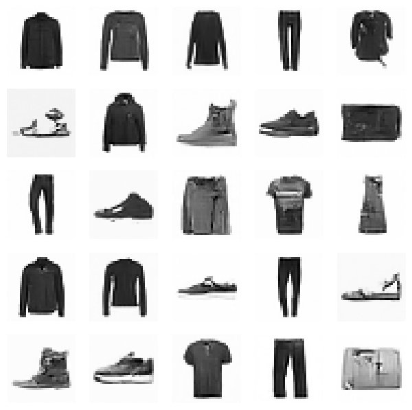

```python
# Scale and display
s = samples[-1] * 2
show_images(s[:25], imsize=1.5)
```

```python
# Evaluate our implementation
ie.fid(s), ie.kid(s)
```

```
(2.420196533203125, 0.016794484108686447)
```

Our implementation achieves similar results to the diffusers library!

## Triangular Noise Distribution

A training improvement: instead of sampling timesteps uniformly, we can use a **triangular distribution** that samples more from the middle timesteps where learning is most important.

```python
def noisify(x0, alphabar):
    """
    Add noise to images using triangular timestep sampling.

    Instead of uniform sampling, this uses a triangular distribution
    that peaks at t=0.5*n_steps. This can improve training because:
    - Very low t: Almost no noise, easy to denoise
    - Very high t: Almost pure noise, hard to learn from
    - Middle t: Most informative for learning

    Args:
        x0: Clean images
        alphabar: Alphabar schedule (cumulative alpha products)

    Returns:
        ((noisy_images, timesteps), noise)
    """
    device = x0.device
    n = len(x0)

    # Original uniform sampling (commented out)
    # t = torch.randint(0, n_steps, (n,), dtype=torch.long)

    # Triangular sampling: peak at 0.5 (middle)
    # np.random.triangular(left, mode, right, size)
    # - left=0: minimum value
    # - mode=0.5: peak of distribution (most likely value)
    # - right=1: maximum value
    t = np.random.triangular(0, 0.5, 1, (n,)) * n_steps
    t = tensor(t, dtype=torch.long)

    # Generate random noise
    epsilon = torch.randn(x0.shape, device=device)

    # Get alphabar for sampled timesteps
    alphabar_t = alphabar[t].reshape(-1, 1, 1, 1).to(device)

    # Apply forward diffusion
    xt = alphabar_t.sqrt() * x0 + (1 - alphabar_t).sqrt() * epsilon

    return (xt, t.to(device)), epsilon
```

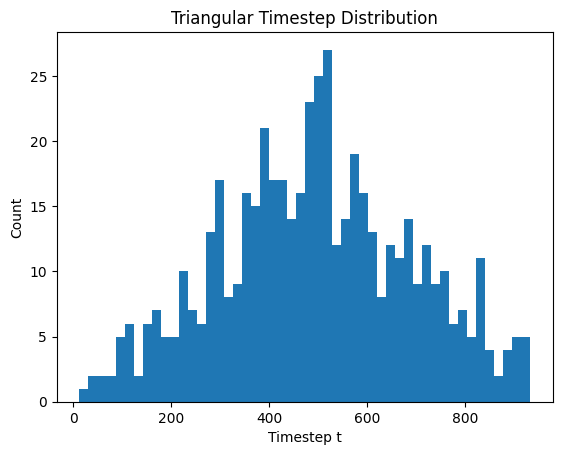

```python
# Visualize the triangular distribution
(xt, t), epsilon = noisify(xb, abar)
plt.hist(t.numpy(), bins=50)
plt.xlabel('Timestep t')
plt.ylabel('Count')
plt.title('Triangular Timestep Distribution');
```

**Triangular vs Uniform Distribution:**

```
Uniform:                    Triangular:

Count                      Count
  |  ________________        |      /\
  | |                |       |     /  \
  | |                |       |    /    \
  | |                |       |   /      \
  | |________________|       |__/________\__
  +------------------        +------------------
  0        500      1000     0   500        1000
         timestep                 timestep

Uniform: Equal probability for all timesteps
Triangular: More samples from middle timesteps (mode=0.5)
```

The triangular distribution focuses training on the middle timesteps where the model can learn the most meaningful denoising patterns.

### 🎮 Interactive: uniform vs triangular timestep sampling

The histogram comparison above, live — and honest about statistics: press **🎲 Draw 100** and watch each training example *fall* into its bin; with few samples both histograms are lumpy, and only with thousands do they converge to the dashed **exact expected shapes** (flat line vs tent — both charts share one y-axis, so the 2× peak is directly visible). A race bar tracks each strategy's share of samples landing in the information-rich middle third (theory: 33.3% vs 55.6%), and chip ④ pulses through the three "why" cards.

**Things to try:** draw ~100 and try to tell the histograms apart, then draw 5000 more; verify the tent peaks at ~2× the uniform level; remember this is a *training-time* trick, independent of (and stackable with) DDIM's *sampling-time* speedup.

```python
# ============================================================================
# INTERACTIVE -- run this cell. It loads ./interactive_viz/ddim_triangular_noise.html
# at full width, sized to fit the visualization (setup cell near the top required).
# Falling-sample animation; exact expected-shape overlays; shared y-axis; middle-third race.
# ============================================================================
show_viz("interactive_viz/ddim_triangular_noise.html", height="960px")
```

[interactive chart not shown]

## Summary

### The DDIM Formula

```
1. Predict x_0: x̂_0 = (x_t - √(1-ᾱ_t) * ε) / √(ᾱ_t)

2. Compute variance: σ² = η² * (β̄_{t-1}/β̄_t) * (1 - ᾱ_t/ᾱ_{t-1})

3. Update: x_{t-1} = √(ᾱ_{t-1}) * x̂_0 + √(β̄_{t-1} - σ²) * ε + σ * z
```

### Training Improvement

- **Triangular sampling**: Sample more middle timesteps during training
- This focuses learning on the most informative noise levels

### Practical Tips

1. Start with 100-200 DDIM steps for a good speed/quality balance
2. Use η=0 for reproducible results, η=1 for more variety
3. Match the scheduler's beta_end to what the model was trained with
4. The diffusers library makes it easy to swap schedulers

## Next Steps

- **Classifier-Free Guidance**: Condition generation on class labels
- **More Advanced Schedulers**: DPM-Solver, UniPC (even faster)
- **Latent Diffusion**: Work in compressed latent space (Stable Diffusion)
- **Image-to-Image**: Start from an existing image instead of pure noise